# Risk Factor Analysis

## Outcome Variable

**Outcome Variable:** ever_swasted

## Predictor Variables

**Intervention Variable:** birthwt

**Adjustment Set:**

- arm
- sex
- W_mage
- meducyrs
- feducyrs
- vagbrth
- single
- brthmon
- W_parity
- delta_W_mage
- delta_meducyrs
- delta_feducyrs
- delta_vagbrth
- delta_single
- delta_brthmon
- delta_W_parity

## Stratifying Variables

The analysis was stratified on these variable(s):

- agecat
- studyid
- country

## Data Summary

| agecat | studyid | country | birthwt | ever_swasted | n_cell | n |
| --- | --- | --- | --- | --- | --- | --- |
| 0-24 months (no birth wast) | ki0047075b-MAL-ED | BANGLADESH | Normal or high birthweight | 0 | 196 | 260 |
| 0-24 months (no birth wast) | ki0047075b-MAL-ED | BANGLADESH | Normal or high birthweight | 1 | 9 | 260 |
| 0-24 months (no birth wast) | ki0047075b-MAL-ED | BANGLADESH | Low birthweight | 0 | 52 | 260 |
| 0-24 months (no birth wast) | ki0047075b-MAL-ED | BANGLADESH | Low birthweight | 1 | 3 | 260 |
| 0-24 months (no birth wast) | ki0047075b-MAL-ED | BRAZIL | Normal or high birthweight | 0 | 217 | 233 |
| 0-24 months (no birth wast) | ki0047075b-MAL-ED | BRAZIL | Normal or high birthweight | 1 | 4 | 233 |
| 0-24 months (no birth wast) | ki0047075b-MAL-ED | BRAZIL | Low birthweight | 0 | 12 | 233 |
| 0-24 months (no birth wast) | ki0047075b-MAL-ED | BRAZIL | Low birthweight | 1 | 0 | 233 |
| 0-24 months (no birth wast) | ki0047075b-MAL-ED | INDIA | Normal or high birthweight | 0 | 190 | 236 |
| 0-24 months (no birth wast) | ki0047075b-MAL-ED | INDIA | Normal or high birthweight | 1 | 12 | 236 |
| 0-24 months (no birth wast) | ki0047075b-MAL-ED | INDIA | Low birthweight | 0 | 34 | 236 |
| 0-24 months (no birth wast) | ki0047075b-MAL-ED | INDIA | Low birthweight | 1 | 0 | 236 |
| 0-24 months (no birth wast) | ki0047075b-MAL-ED | NEPAL | Normal or high birthweight | 0 | 212 | 232 |
| 0-24 months (no birth wast) | ki0047075b-MAL-ED | NEPAL | Normal or high birthweight | 1 | 1 | 232 |
| 0-24 months (no birth wast) | ki0047075b-MAL-ED | NEPAL | Low birthweight | 0 | 19 | 232 |
| 0-24 months (no birth wast) | ki0047075b-MAL-ED | NEPAL | Low birthweight | 1 | 0 | 232 |
| 0-24 months (no birth wast) | ki0047075b-MAL-ED | PERU | Normal or high birthweight | 0 | 278 | 299 |
| 0-24 months (no birth wast) | ki0047075b-MAL-ED | PERU | Normal or high birthweight | 1 | 4 | 299 |
| 0-24 months (no birth wast) | ki0047075b-MAL-ED | PERU | Low birthweight | 0 | 17 | 299 |
| 0-24 months (no birth wast) | ki0047075b-MAL-ED | PERU | Low birthweight | 1 | 0 | 299 |
| 0-24 months (no birth wast) | ki0047075b-MAL-ED | SOUTH AFRICA | Normal or high birthweight | 0 | 276 | 306 |
| 0-24 months (no birth wast) | ki0047075b-MAL-ED | SOUTH AFRICA | Normal or high birthweight | 1 | 11 | 306 |
| 0-24 months (no birth wast) | ki0047075b-MAL-ED | SOUTH AFRICA | Low birthweight | 0 | 18 | 306 |
| 0-24 months (no birth wast) | ki0047075b-MAL-ED | SOUTH AFRICA | Low birthweight | 1 | 1 | 306 |
| 0-24 months (no birth wast) | ki0047075b-MAL-ED | TANZANIA, UNITED REPUBLIC OF | Normal or high birthweight | 0 | 180 | 196 |
| 0-24 months (no birth wast) | ki0047075b-MAL-ED | TANZANIA, UNITED REPUBLIC OF | Normal or high birthweight | 1 | 6 | 196 |
| 0-24 months (no birth wast) | ki0047075b-MAL-ED | TANZANIA, UNITED REPUBLIC OF | Low birthweight | 0 | 10 | 196 |
| 0-24 months (no birth wast) | ki0047075b-MAL-ED | TANZANIA, UNITED REPUBLIC OF | Low birthweight | 1 | 0 | 196 |
| 0-24 months (no birth wast) | ki1000108-CMC-V-BCS-2002 | INDIA | Normal or high birthweight | 0 | 278 | 368 |
| 0-24 months (no birth wast) | ki1000108-CMC-V-BCS-2002 | INDIA | Normal or high birthweight | 1 | 50 | 368 |

[output cut: 294 more lines]

The following strata were considered:

- agecat: 0-24 months (no birth wast), studyid: ki0047075b-MAL-ED, country: BANGLADESH
- agecat: 0-24 months (no birth wast), studyid: ki0047075b-MAL-ED, country: BRAZIL
- agecat: 0-24 months (no birth wast), studyid: ki0047075b-MAL-ED, country: INDIA
- agecat: 0-24 months (no birth wast), studyid: ki0047075b-MAL-ED, country: NEPAL
- agecat: 0-24 months (no birth wast), studyid: ki0047075b-MAL-ED, country: PERU
- agecat: 0-24 months (no birth wast), studyid: ki0047075b-MAL-ED, country: SOUTH AFRICA
- agecat: 0-24 months (no birth wast), studyid: ki0047075b-MAL-ED, country: TANZANIA, UNITED REPUBLIC OF
- agecat: 0-24 months (no birth wast), studyid: ki1000108-CMC-V-BCS-2002, country: INDIA
- agecat: 0-24 months (no birth wast), studyid: ki1000108-IRC, country: INDIA
- agecat: 0-24 months (no birth wast), studyid: ki1000109-EE, country: PAKISTAN
- agecat: 0-24 months (no birth wast), studyid: ki1000109-ResPak, country: PAKISTAN
- agecat: 0-24 months (no birth wast), studyid: ki1000304b-SAS-CompFeed, country: INDIA
- agecat: 0-24 months (no birth wast), studyid: ki1017093-NIH-Birth, country: BANGLADESH
- agecat: 0-24 months (no birth wast), studyid: ki1017093b-PROVIDE, country: BANGLADESH
- agecat: 0-24 months (no birth wast), studyid: ki1017093c-NIH-Crypto, country: BANGLADESH
- agecat: 0-24 months (no birth wast), studyid: ki1066203-TanzaniaChild2, country: TANZANIA, UNITED REPUBLIC OF
- agecat: 0-24 months (no birth wast), studyid: ki1101329-Keneba, country: GAMBIA
- agecat: 0-24 months (no birth wast), studyid: ki1113344-GMS-Nepal, country: NEPAL
- agecat: 0-24 months (no birth wast), studyid: ki1114097-CMIN, country: BANGLADESH
- agecat: 0-24 months (no birth wast), studyid: ki1114097-CONTENT, country: PERU
- agecat: 0-24 months (no birth wast), studyid: ki1119695-PROBIT, country: BELARUS
- agecat: 0-24 months (no birth wast), studyid: ki1126311-ZVITAMBO, country: ZIMBABWE
- agecat: 0-24 months (no birth wast), studyid: ki1135781-COHORTS, country: GUATEMALA
- agecat: 0-24 months (no birth wast), studyid: ki1135781-COHORTS, country: INDIA
- agecat: 0-24 months (no birth wast), studyid: ki1135781-COHORTS, country: PHILIPPINES
- agecat: 0-24 months (no birth wast), studyid: kiGH5241-JiVitA-3, country: BANGLADESH
- agecat: 0-24 months (no birth wast), studyid: kiGH5241-JiVitA-4, country: BANGLADESH
- agecat: 0-6 months (no birth wast), studyid: ki0047075b-MAL-ED, country: BANGLADESH
- agecat: 0-6 months (no birth wast), studyid: ki0047075b-MAL-ED, country: BRAZIL
- agecat: 0-6 months (no birth wast), studyid: ki0047075b-MAL-ED, country: INDIA
- agecat: 0-6 months (no birth wast), studyid: ki0047075b-MAL-ED, country: NEPAL
- agecat: 0-6 months (no birth wast), studyid: ki0047075b-MAL-ED, country: PERU
- agecat: 0-6 months (no birth wast), studyid: ki0047075b-MAL-ED, country: SOUTH AFRICA
- agecat: 0-6 months (no birth wast), studyid: ki0047075b-MAL-ED, country: TANZANIA, UNITED REPUBLIC OF
- agecat: 0-6 months (no birth wast), studyid: ki1000108-CMC-V-BCS-2002, country: INDIA
- agecat: 0-6 months (no birth wast), studyid: ki1000108-IRC, country: INDIA
- agecat: 0-6 months (no birth wast), studyid: ki1000109-EE, country: PAKISTAN
- agecat: 0-6 months (no birth wast), studyid: ki1000109-ResPak, country: PAKISTAN
- agecat: 0-6 months (no birth wast), studyid: ki1000304b-SAS-CompFeed, country: INDIA
- agecat: 0-6 months (no birth wast), studyid: ki1017093-NIH-Birth, country: BANGLADESH
- agecat: 0-6 months (no birth wast), studyid: ki1017093b-PROVIDE, country: BANGLADESH
- agecat: 0-6 months (no birth wast), studyid: ki1017093c-NIH-Crypto, country: BANGLADESH
- agecat: 0-6 months (no birth wast), studyid: ki1066203-TanzaniaChild2, country: TANZANIA, UNITED REPUBLIC OF
- agecat: 0-6 months (no birth wast), studyid: ki1101329-Keneba, country: GAMBIA
- agecat: 0-6 months (no birth wast), studyid: ki1113344-GMS-Nepal, country: NEPAL
- agecat: 0-6 months (no birth wast), studyid: ki1114097-CMIN, country: BANGLADESH
- agecat: 0-6 months (no birth wast), studyid: ki1114097-CONTENT, country: PERU
- agecat: 0-6 months (no birth wast), studyid: ki1119695-PROBIT, country: BELARUS
- agecat: 0-6 months (no birth wast), studyid: ki1126311-ZVITAMBO, country: ZIMBABWE
- agecat: 0-6 months (no birth wast), studyid: ki1135781-COHORTS, country: GUATEMALA
- agecat: 0-6 months (no birth wast), studyid: ki1135781-COHORTS, country: INDIA
- agecat: 0-6 months (no birth wast), studyid: ki1135781-COHORTS, country: PHILIPPINES
- agecat: 0-6 months (no birth wast), studyid: kiGH5241-JiVitA-3, country: BANGLADESH
- agecat: 0-6 months (no birth wast), studyid: kiGH5241-JiVitA-4, country: BANGLADESH
- agecat: 6-24 months, studyid: ki0047075b-MAL-ED, country: BANGLADESH
- agecat: 6-24 months, studyid: ki0047075b-MAL-ED, country: BRAZIL
- agecat: 6-24 months, studyid: ki0047075b-MAL-ED, country: INDIA
- agecat: 6-24 months, studyid: ki0047075b-MAL-ED, country: NEPAL
- agecat: 6-24 months, studyid: ki0047075b-MAL-ED, country: PERU
- agecat: 6-24 months, studyid: ki0047075b-MAL-ED, country: SOUTH AFRICA
- agecat: 6-24 months, studyid: ki0047075b-MAL-ED, country: TANZANIA, UNITED REPUBLIC OF
- agecat: 6-24 months, studyid: ki1000108-CMC-V-BCS-2002, country: INDIA
- agecat: 6-24 months, studyid: ki1000108-IRC, country: INDIA
- agecat: 6-24 months, studyid: ki1000109-EE, country: PAKISTAN
- agecat: 6-24 months, studyid: ki1000109-ResPak, country: PAKISTAN
- agecat: 6-24 months, studyid: ki1000304b-SAS-CompFeed, country: INDIA
- agecat: 6-24 months, studyid: ki1017093-NIH-Birth, country: BANGLADESH
- agecat: 6-24 months, studyid: ki1017093b-PROVIDE, country: BANGLADESH
- agecat: 6-24 months, studyid: ki1017093c-NIH-Crypto, country: BANGLADESH
- agecat: 6-24 months, studyid: ki1066203-TanzaniaChild2, country: TANZANIA, UNITED REPUBLIC OF
- agecat: 6-24 months, studyid: ki1101329-Keneba, country: GAMBIA
- agecat: 6-24 months, studyid: ki1113344-GMS-Nepal, country: NEPAL
- agecat: 6-24 months, studyid: ki1114097-CMIN, country: BANGLADESH
- agecat: 6-24 months, studyid: ki1114097-CONTENT, country: PERU
- agecat: 6-24 months, studyid: ki1119695-PROBIT, country: BELARUS
- agecat: 6-24 months, studyid: ki1126311-ZVITAMBO, country: ZIMBABWE
- agecat: 6-24 months, studyid: ki1135781-COHORTS, country: GUATEMALA
- agecat: 6-24 months, studyid: ki1135781-COHORTS, country: INDIA
- agecat: 6-24 months, studyid: ki1135781-COHORTS, country: PHILIPPINES
- agecat: 6-24 months, studyid: kiGH5241-JiVitA-3, country: BANGLADESH
- agecat: 6-24 months, studyid: kiGH5241-JiVitA-4, country: BANGLADESH

### Dropped Strata

Some strata were dropped due to rare outcomes:

- agecat: 0-24 months (no birth wast), studyid: ki0047075b-MAL-ED, country: BANGLADESH
- agecat: 0-24 months (no birth wast), studyid: ki0047075b-MAL-ED, country: BRAZIL
- agecat: 0-24 months (no birth wast), studyid: ki0047075b-MAL-ED, country: INDIA
- agecat: 0-24 months (no birth wast), studyid: ki0047075b-MAL-ED, country: NEPAL
- agecat: 0-24 months (no birth wast), studyid: ki0047075b-MAL-ED, country: PERU
- agecat: 0-24 months (no birth wast), studyid: ki0047075b-MAL-ED, country: SOUTH AFRICA
- agecat: 0-24 months (no birth wast), studyid: ki0047075b-MAL-ED, country: TANZANIA, UNITED REPUBLIC OF
- agecat: 0-24 months (no birth wast), studyid: ki1000109-ResPak, country: PAKISTAN
- agecat: 0-24 months (no birth wast), studyid: ki1114097-CMIN, country: BANGLADESH
- agecat: 0-24 months (no birth wast), studyid: ki1114097-CONTENT, country: PERU
- agecat: 0-24 months (no birth wast), studyid: ki1119695-PROBIT, country: BELARUS
- agecat: 0-6 months (no birth wast), studyid: ki0047075b-MAL-ED, country: BANGLADESH
- agecat: 0-6 months (no birth wast), studyid: ki0047075b-MAL-ED, country: BRAZIL
- agecat: 0-6 months (no birth wast), studyid: ki0047075b-MAL-ED, country: INDIA
- agecat: 0-6 months (no birth wast), studyid: ki0047075b-MAL-ED, country: NEPAL
- agecat: 0-6 months (no birth wast), studyid: ki0047075b-MAL-ED, country: PERU
- agecat: 0-6 months (no birth wast), studyid: ki0047075b-MAL-ED, country: SOUTH AFRICA
- agecat: 0-6 months (no birth wast), studyid: ki0047075b-MAL-ED, country: TANZANIA, UNITED REPUBLIC OF
- agecat: 0-6 months (no birth wast), studyid: ki1000108-CMC-V-BCS-2002, country: INDIA
- agecat: 0-6 months (no birth wast), studyid: ki1000109-ResPak, country: PAKISTAN
- agecat: 0-6 months (no birth wast), studyid: ki1017093-NIH-Birth, country: BANGLADESH
- agecat: 0-6 months (no birth wast), studyid: ki1017093b-PROVIDE, country: BANGLADESH
- agecat: 0-6 months (no birth wast), studyid: ki1017093c-NIH-Crypto, country: BANGLADESH
- agecat: 0-6 months (no birth wast), studyid: ki1066203-TanzaniaChild2, country: TANZANIA, UNITED REPUBLIC OF
- agecat: 0-6 months (no birth wast), studyid: ki1114097-CMIN, country: BANGLADESH
- agecat: 0-6 months (no birth wast), studyid: ki1114097-CONTENT, country: PERU
- agecat: 0-6 months (no birth wast), studyid: ki1119695-PROBIT, country: BELARUS
- agecat: 0-6 months (no birth wast), studyid: ki1135781-COHORTS, country: GUATEMALA
- agecat: 6-24 months, studyid: ki0047075b-MAL-ED, country: BANGLADESH
- agecat: 6-24 months, studyid: ki0047075b-MAL-ED, country: BRAZIL
- agecat: 6-24 months, studyid: ki0047075b-MAL-ED, country: INDIA
- agecat: 6-24 months, studyid: ki0047075b-MAL-ED, country: NEPAL
- agecat: 6-24 months, studyid: ki0047075b-MAL-ED, country: PERU
- agecat: 6-24 months, studyid: ki0047075b-MAL-ED, country: SOUTH AFRICA
- agecat: 6-24 months, studyid: ki0047075b-MAL-ED, country: TANZANIA, UNITED REPUBLIC OF
- agecat: 6-24 months, studyid: ki1000109-ResPak, country: PAKISTAN
- agecat: 6-24 months, studyid: ki1114097-CMIN, country: BANGLADESH
- agecat: 6-24 months, studyid: ki1114097-CONTENT, country: PERU
- agecat: 6-24 months, studyid: ki1119695-PROBIT, country: BELARUS

## Methods Detail

We’re interested in the causal parameters $E[Y_a]$ for all values of $a \in \mathcal{A}$. These parameters represent the mean outcome if, possibly contrary to fact, we intervened to set all units to have $A=a$. Under the randomization and positivity assumptions, these are identified by the statistical parameters $\psi_a=E_W[E_{Y|A,W}(Y|A=a,W)]$. In addition, we’re interested in the mean of $Y$, $E[Y]$ under no intervention (the observed mean). We will estimate these parameters by using SuperLearner to fit the relevant likelihood factors – $E_{Y|A,W}(Y|A=a,W)$ and $p(A=a|W)$, and then updating our likelihood fit using a joint TMLE.

For unadjusted analyses ($W=\{\}$), initial likelihoods were estimated using Lrnr_glm to estimate the simple $E(Y|A)$ and Lrnr_mean to estimate $p(A)$. For adjusted analyses, a small library containing Lrnr_glmnet, Lrnr_xgboost, and Lrnr_mean was used.

Having estimated these parameters, we will then use the delta method to estimate relative risks and attributable risks relative to a prespecified baseline level of $A$.

# Results Detail

## Results Plots

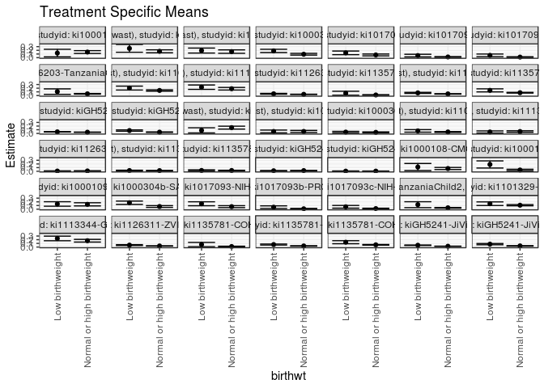

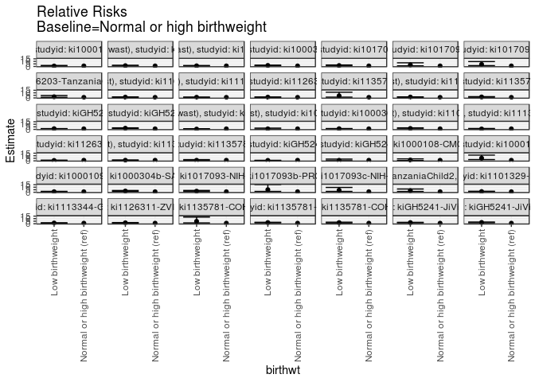

[figure not shown]

[figure not shown]

## Results Table

### Parameter: TSM

| agecat | studyid | country | intervention_level | baseline_level | estimate | ci_lower | ci_upper |
| --- | --- | --- | --- | --- | --- | --- | --- |
| 0-24 months (no birth wast) | ki1000108-CMC-V-BCS-2002 | INDIA | Normal or high birthweight | NA | 0.1524390 | 0.1134865 | 0.1913915 |
| 0-24 months (no birth wast) | ki1000108-CMC-V-BCS-2002 | INDIA | Low birthweight | NA | 0.1250000 | 0.0223715 | 0.2276285 |
| 0-24 months (no birth wast) | ki1000108-IRC | INDIA | Normal or high birthweight | NA | 0.1726995 | 0.1321756 | 0.2132233 |
| 0-24 months (no birth wast) | ki1000108-IRC | INDIA | Low birthweight | NA | 0.2521666 | 0.1475578 | 0.3567753 |
| 0-24 months (no birth wast) | ki1000109-EE | PAKISTAN | Normal or high birthweight | NA | 0.1650354 | 0.1181910 | 0.2118799 |
| 0-24 months (no birth wast) | ki1000109-EE | PAKISTAN | Low birthweight | NA | 0.1932020 | 0.1253088 | 0.2610952 |
| 0-24 months (no birth wast) | ki1000304b-SAS-CompFeed | INDIA | Normal or high birthweight | NA | 0.0933467 | 0.0703683 | 0.1163252 |
| 0-24 months (no birth wast) | ki1000304b-SAS-CompFeed | INDIA | Low birthweight | NA | 0.1836656 | 0.1394396 | 0.2278917 |
| 0-24 months (no birth wast) | ki1017093-NIH-Birth | BANGLADESH | Normal or high birthweight | NA | 0.0742245 | 0.0488149 | 0.0996341 |
| 0-24 months (no birth wast) | ki1017093-NIH-Birth | BANGLADESH | Low birthweight | NA | 0.1307271 | 0.0811901 | 0.1802640 |
| 0-24 months (no birth wast) | ki1017093b-PROVIDE | BANGLADESH | Normal or high birthweight | NA | 0.0189394 | 0.0073041 | 0.0305747 |
| 0-24 months (no birth wast) | ki1017093b-PROVIDE | BANGLADESH | Low birthweight | NA | 0.0566038 | 0.0206590 | 0.0925485 |
| 0-24 months (no birth wast) | ki1017093c-NIH-Crypto | BANGLADESH | Normal or high birthweight | NA | 0.0155440 | 0.0054613 | 0.0256267 |
| 0-24 months (no birth wast) | ki1017093c-NIH-Crypto | BANGLADESH | Low birthweight | NA | 0.0628571 | 0.0268741 | 0.0988402 |
| 0-24 months (no birth wast) | ki1066203-TanzaniaChild2 | TANZANIA, UNITED REPUBLIC OF | Normal or high birthweight | NA | 0.0473748 | 0.0386490 | 0.0561006 |
| 0-24 months (no birth wast) | ki1066203-TanzaniaChild2 | TANZANIA, UNITED REPUBLIC OF | Low birthweight | NA | 0.1070668 | 0.0325402 | 0.1815935 |
| 0-24 months (no birth wast) | ki1101329-Keneba | GAMBIA | Normal or high birthweight | NA | 0.1388287 | 0.1200429 | 0.1576144 |
| 0-24 months (no birth wast) | ki1101329-Keneba | GAMBIA | Low birthweight | NA | 0.2033024 | 0.1499077 | 0.2566971 |
| 0-24 months (no birth wast) | ki1113344-GMS-Nepal | NEPAL | Normal or high birthweight | NA | 0.1855402 | 0.1502283 | 0.2208521 |
| 0-24 months (no birth wast) | ki1113344-GMS-Nepal | NEPAL | Low birthweight | NA | 0.2275188 | 0.1678610 | 0.2871766 |
| 0-24 months (no birth wast) | ki1126311-ZVITAMBO | ZIMBABWE | Normal or high birthweight | NA | 0.0332876 | 0.0300641 | 0.0365111 |
| 0-24 months (no birth wast) | ki1126311-ZVITAMBO | ZIMBABWE | Low birthweight | NA | 0.0479206 | 0.0374146 | 0.0584266 |
| 0-24 months (no birth wast) | ki1135781-COHORTS | GUATEMALA | Normal or high birthweight | NA | 0.0155131 | 0.0071413 | 0.0238849 |
| 0-24 months (no birth wast) | ki1135781-COHORTS | GUATEMALA | Low birthweight | NA | 0.0632911 | 0.0095700 | 0.1170123 |
| 0-24 months (no birth wast) | ki1135781-COHORTS | INDIA | Normal or high birthweight | NA | 0.0453861 | 0.0397890 | 0.0509833 |
| 0-24 months (no birth wast) | ki1135781-COHORTS | INDIA | Low birthweight | NA | 0.0727312 | 0.0581901 | 0.0872722 |
| 0-24 months (no birth wast) | ki1135781-COHORTS | PHILIPPINES | Normal or high birthweight | NA | 0.0773380 | 0.0672625 | 0.0874134 |
| 0-24 months (no birth wast) | ki1135781-COHORTS | PHILIPPINES | Low birthweight | NA | 0.1411677 | 0.0998288 | 0.1825067 |
| 0-24 months (no birth wast) | kiGH5241-JiVitA-3 | BANGLADESH | Normal or high birthweight | NA | 0.0333731 | 0.0298070 | 0.0369391 |
| 0-24 months (no birth wast) | kiGH5241-JiVitA-3 | BANGLADESH | Low birthweight | NA | 0.0433173 | 0.0385432 | 0.0480913 |

[output cut: 54 more lines]

### Parameter: E(Y)

| agecat | studyid | country | intervention_level | baseline_level | estimate | ci_lower | ci_upper |
| --- | --- | --- | --- | --- | --- | --- | --- |
| 0-24 months (no birth wast) | ki1000108-CMC-V-BCS-2002 | INDIA | NA | NA | 0.1494565 | 0.1129794 | 0.1859337 |
| 0-24 months (no birth wast) | ki1000108-IRC | INDIA | NA | NA | 0.1861042 | 0.1480592 | 0.2241492 |
| 0-24 months (no birth wast) | ki1000109-EE | PAKISTAN | NA | NA | 0.1755319 | 0.1370287 | 0.2140352 |
| 0-24 months (no birth wast) | ki1000304b-SAS-CompFeed | INDIA | NA | NA | 0.1146113 | 0.0915227 | 0.1376999 |
| 0-24 months (no birth wast) | ki1017093-NIH-Birth | BANGLADESH | NA | NA | 0.0912220 | 0.0677898 | 0.1146542 |
| 0-24 months (no birth wast) | ki1017093b-PROVIDE | BANGLADESH | NA | NA | 0.0276565 | 0.0153851 | 0.0399279 |
| 0-24 months (no birth wast) | ki1017093c-NIH-Crypto | BANGLADESH | NA | NA | 0.0265252 | 0.0150478 | 0.0380026 |
| 0-24 months (no birth wast) | ki1066203-TanzaniaChild2 | TANZANIA, UNITED REPUBLIC OF | NA | NA | 0.0500212 | 0.0412227 | 0.0588197 |
| 0-24 months (no birth wast) | ki1101329-Keneba | GAMBIA | NA | NA | 0.1474234 | 0.1296705 | 0.1651762 |
| 0-24 months (no birth wast) | ki1113344-GMS-Nepal | NEPAL | NA | NA | 0.1987860 | 0.1682929 | 0.2292792 |
| 0-24 months (no birth wast) | ki1126311-ZVITAMBO | ZIMBABWE | NA | NA | 0.0350916 | 0.0319981 | 0.0381851 |
| 0-24 months (no birth wast) | ki1135781-COHORTS | GUATEMALA | NA | NA | 0.0196292 | 0.0106457 | 0.0286128 |
| 0-24 months (no birth wast) | ki1135781-COHORTS | INDIA | NA | NA | 0.0505825 | 0.0452644 | 0.0559005 |
| 0-24 months (no birth wast) | ki1135781-COHORTS | PHILIPPINES | NA | NA | 0.0833613 | 0.0734265 | 0.0932961 |
| 0-24 months (no birth wast) | kiGH5241-JiVitA-3 | BANGLADESH | NA | NA | 0.0376119 | 0.0347245 | 0.0404993 |
| 0-24 months (no birth wast) | kiGH5241-JiVitA-4 | BANGLADESH | NA | NA | 0.0463561 | 0.0396916 | 0.0530207 |
| 0-6 months (no birth wast) | ki1000108-IRC | INDIA | NA | NA | 0.1458333 | 0.1104867 | 0.1811800 |
| 0-6 months (no birth wast) | ki1000109-EE | PAKISTAN | NA | NA | 0.0534759 | 0.0306442 | 0.0763077 |
| 0-6 months (no birth wast) | ki1000304b-SAS-CompFeed | INDIA | NA | NA | 0.0313993 | 0.0187576 | 0.0440411 |
| 0-6 months (no birth wast) | ki1101329-Keneba | GAMBIA | NA | NA | 0.0434496 | 0.0331941 | 0.0537052 |
| 0-6 months (no birth wast) | ki1113344-GMS-Nepal | NEPAL | NA | NA | 0.0483619 | 0.0317414 | 0.0649825 |
| 0-6 months (no birth wast) | ki1126311-ZVITAMBO | ZIMBABWE | NA | NA | 0.0098995 | 0.0082190 | 0.0115800 |
| 0-6 months (no birth wast) | ki1135781-COHORTS | INDIA | NA | NA | 0.0194945 | 0.0160113 | 0.0229777 |
| 0-6 months (no birth wast) | ki1135781-COHORTS | PHILIPPINES | NA | NA | 0.0223426 | 0.0170120 | 0.0276732 |
| 0-6 months (no birth wast) | kiGH5241-JiVitA-3 | BANGLADESH | NA | NA | 0.0175574 | 0.0154912 | 0.0196236 |
| 0-6 months (no birth wast) | kiGH5241-JiVitA-4 | BANGLADESH | NA | NA | 0.0048033 | 0.0020515 | 0.0075551 |
| 6-24 months | ki1000108-CMC-V-BCS-2002 | INDIA | NA | NA | 0.0804290 | 0.0527929 | 0.1080650 |
| 6-24 months | ki1000108-IRC | INDIA | NA | NA | 0.0618812 | 0.0383576 | 0.0854048 |
| 6-24 months | ki1000109-EE | PAKISTAN | NA | NA | 0.1367292 | 0.1018167 | 0.1716417 |
| 6-24 months | ki1000304b-SAS-CompFeed | INDIA | NA | NA | 0.0964467 | 0.0724546 | 0.1204388 |
| 6-24 months | ki1017093-NIH-Birth | BANGLADESH | NA | NA | 0.0919540 | 0.0671416 | 0.1167664 |
| 6-24 months | ki1017093b-PROVIDE | BANGLADESH | NA | NA | 0.0211382 | 0.0097604 | 0.0325160 |
| 6-24 months | ki1017093c-NIH-Crypto | BANGLADESH | NA | NA | 0.0273973 | 0.0155476 | 0.0392469 |
| 6-24 months | ki1066203-TanzaniaChild2 | TANZANIA, UNITED REPUBLIC OF | NA | NA | 0.0405405 | 0.0318905 | 0.0491906 |
| 6-24 months | ki1101329-Keneba | GAMBIA | NA | NA | 0.1140530 | 0.0978143 | 0.1302917 |
| 6-24 months | ki1113344-GMS-Nepal | NEPAL | NA | NA | 0.1901528 | 0.1584343 | 0.2218713 |
| 6-24 months | ki1126311-ZVITAMBO | ZIMBABWE | NA | NA | 0.0329314 | 0.0295624 | 0.0363003 |
| 6-24 months | ki1135781-COHORTS | GUATEMALA | NA | NA | 0.0193470 | 0.0099536 | 0.0287404 |
| 6-24 months | ki1135781-COHORTS | INDIA | NA | NA | 0.0381013 | 0.0333732 | 0.0428293 |
| 6-24 months | ki1135781-COHORTS | PHILIPPINES | NA | NA | 0.0676067 | 0.0582484 | 0.0769649 |
| 6-24 months | kiGH5241-JiVitA-3 | BANGLADESH | NA | NA | 0.0331773 | 0.0301204 | 0.0362342 |
| 6-24 months | kiGH5241-JiVitA-4 | BANGLADESH | NA | NA | 0.0442321 | 0.0375131 | 0.0509510 |

### Parameter: RR

| agecat | studyid | country | intervention_level | baseline_level | estimate | ci_lower | ci_upper |
| --- | --- | --- | --- | --- | --- | --- | --- |
| 0-24 months (no birth wast) | ki1000108-CMC-V-BCS-2002 | INDIA | Normal or high birthweight | Normal or high birthweight | 1.0000000 | 1.0000000 | 1.0000000 |
| 0-24 months (no birth wast) | ki1000108-CMC-V-BCS-2002 | INDIA | Low birthweight | Normal or high birthweight | 0.8200000 | 0.3470369 | 1.9375460 |
| 0-24 months (no birth wast) | ki1000108-IRC | INDIA | Normal or high birthweight | Normal or high birthweight | 1.0000000 | 1.0000000 | 1.0000000 |
| 0-24 months (no birth wast) | ki1000108-IRC | INDIA | Low birthweight | Normal or high birthweight | 1.4601467 | 0.9065984 | 2.3516792 |
| 0-24 months (no birth wast) | ki1000109-EE | PAKISTAN | Normal or high birthweight | Normal or high birthweight | 1.0000000 | 1.0000000 | 1.0000000 |
| 0-24 months (no birth wast) | ki1000109-EE | PAKISTAN | Low birthweight | Normal or high birthweight | 1.1706698 | 0.7451750 | 1.8391221 |
| 0-24 months (no birth wast) | ki1000304b-SAS-CompFeed | INDIA | Normal or high birthweight | Normal or high birthweight | 1.0000000 | 1.0000000 | 1.0000000 |
| 0-24 months (no birth wast) | ki1000304b-SAS-CompFeed | INDIA | Low birthweight | Normal or high birthweight | 1.9675635 | 1.4933355 | 2.5923886 |
| 0-24 months (no birth wast) | ki1017093-NIH-Birth | BANGLADESH | Normal or high birthweight | Normal or high birthweight | 1.0000000 | 1.0000000 | 1.0000000 |
| 0-24 months (no birth wast) | ki1017093-NIH-Birth | BANGLADESH | Low birthweight | Normal or high birthweight | 1.7612389 | 1.0568871 | 2.9349990 |
| 0-24 months (no birth wast) | ki1017093b-PROVIDE | BANGLADESH | Normal or high birthweight | Normal or high birthweight | 1.0000000 | 1.0000000 | 1.0000000 |
| 0-24 months (no birth wast) | ki1017093b-PROVIDE | BANGLADESH | Low birthweight | Normal or high birthweight | 2.9886792 | 1.2352498 | 7.2310909 |
| 0-24 months (no birth wast) | ki1017093c-NIH-Crypto | BANGLADESH | Normal or high birthweight | Normal or high birthweight | 1.0000000 | 1.0000000 | 1.0000000 |
| 0-24 months (no birth wast) | ki1017093c-NIH-Crypto | BANGLADESH | Low birthweight | Normal or high birthweight | 4.0438095 | 1.7024219 | 9.6053718 |
| 0-24 months (no birth wast) | ki1066203-TanzaniaChild2 | TANZANIA, UNITED REPUBLIC OF | Normal or high birthweight | Normal or high birthweight | 1.0000000 | 1.0000000 | 1.0000000 |
| 0-24 months (no birth wast) | ki1066203-TanzaniaChild2 | TANZANIA, UNITED REPUBLIC OF | Low birthweight | Normal or high birthweight | 2.2599940 | 1.0999823 | 4.6433226 |
| 0-24 months (no birth wast) | ki1101329-Keneba | GAMBIA | Normal or high birthweight | Normal or high birthweight | 1.0000000 | 1.0000000 | 1.0000000 |
| 0-24 months (no birth wast) | ki1101329-Keneba | GAMBIA | Low birthweight | Normal or high birthweight | 1.4644123 | 1.0903343 | 1.9668311 |
| 0-24 months (no birth wast) | ki1113344-GMS-Nepal | NEPAL | Normal or high birthweight | Normal or high birthweight | 1.0000000 | 1.0000000 | 1.0000000 |
| 0-24 months (no birth wast) | ki1113344-GMS-Nepal | NEPAL | Low birthweight | Normal or high birthweight | 1.2262507 | 0.8876542 | 1.6940053 |
| 0-24 months (no birth wast) | ki1126311-ZVITAMBO | ZIMBABWE | Normal or high birthweight | Normal or high birthweight | 1.0000000 | 1.0000000 | 1.0000000 |
| 0-24 months (no birth wast) | ki1126311-ZVITAMBO | ZIMBABWE | Low birthweight | Normal or high birthweight | 1.4395942 | 1.1328391 | 1.8294137 |
| 0-24 months (no birth wast) | ki1135781-COHORTS | GUATEMALA | Normal or high birthweight | Normal or high birthweight | 1.0000000 | 1.0000000 | 1.0000000 |
| 0-24 months (no birth wast) | ki1135781-COHORTS | GUATEMALA | Low birthweight | Normal or high birthweight | 4.0798442 | 1.4921752 | 11.1549428 |
| 0-24 months (no birth wast) | ki1135781-COHORTS | INDIA | Normal or high birthweight | Normal or high birthweight | 1.0000000 | 1.0000000 | 1.0000000 |
| 0-24 months (no birth wast) | ki1135781-COHORTS | INDIA | Low birthweight | Normal or high birthweight | 1.6024987 | 1.2669804 | 2.0268680 |
| 0-24 months (no birth wast) | ki1135781-COHORTS | PHILIPPINES | Normal or high birthweight | Normal or high birthweight | 1.0000000 | 1.0000000 | 1.0000000 |
| 0-24 months (no birth wast) | ki1135781-COHORTS | PHILIPPINES | Low birthweight | Normal or high birthweight | 1.8253353 | 1.3250434 | 2.5145206 |
| 0-24 months (no birth wast) | kiGH5241-JiVitA-3 | BANGLADESH | Normal or high birthweight | Normal or high birthweight | 1.0000000 | 1.0000000 | 1.0000000 |
| 0-24 months (no birth wast) | kiGH5241-JiVitA-3 | BANGLADESH | Low birthweight | Normal or high birthweight | 1.2979704 | 1.1152198 | 1.5106681 |

[output cut: 54 more lines]

### Parameter: PAR

| agecat | studyid | country | intervention_level | baseline_level | estimate | ci_lower | ci_upper |
| --- | --- | --- | --- | --- | --- | --- | --- |
| 0-24 months (no birth wast) | ki1000108-CMC-V-BCS-2002 | INDIA | Normal or high birthweight | NA | -0.0029825 | -0.0149462 | 0.0089812 |
| 0-24 months (no birth wast) | ki1000108-IRC | INDIA | Normal or high birthweight | NA | 0.0134048 | -0.0054871 | 0.0322966 |
| 0-24 months (no birth wast) | ki1000109-EE | PAKISTAN | Normal or high birthweight | NA | 0.0104965 | -0.0187397 | 0.0397326 |
| 0-24 months (no birth wast) | ki1000304b-SAS-CompFeed | INDIA | Normal or high birthweight | NA | 0.0212645 | 0.0119767 | 0.0305523 |
| 0-24 months (no birth wast) | ki1017093-NIH-Birth | BANGLADESH | Normal or high birthweight | NA | 0.0169975 | 0.0003716 | 0.0336235 |
| 0-24 months (no birth wast) | ki1017093b-PROVIDE | BANGLADESH | Normal or high birthweight | NA | 0.0087171 | -0.0001074 | 0.0175416 |
| 0-24 months (no birth wast) | ki1017093c-NIH-Crypto | BANGLADESH | Normal or high birthweight | NA | 0.0109812 | 0.0021914 | 0.0197709 |
| 0-24 months (no birth wast) | ki1066203-TanzaniaChild2 | TANZANIA, UNITED REPUBLIC OF | Normal or high birthweight | NA | 0.0026464 | 0.0001044 | 0.0051883 |
| 0-24 months (no birth wast) | ki1101329-Keneba | GAMBIA | Normal or high birthweight | NA | 0.0085947 | 0.0005144 | 0.0166750 |
| 0-24 months (no birth wast) | ki1113344-GMS-Nepal | NEPAL | Normal or high birthweight | NA | 0.0132458 | -0.0066108 | 0.0331024 |
| 0-24 months (no birth wast) | ki1126311-ZVITAMBO | ZIMBABWE | Normal or high birthweight | NA | 0.0018040 | 0.0004884 | 0.0031197 |
| 0-24 months (no birth wast) | ki1135781-COHORTS | GUATEMALA | Normal or high birthweight | NA | 0.0041161 | -0.0006476 | 0.0088798 |
| 0-24 months (no birth wast) | ki1135781-COHORTS | INDIA | Normal or high birthweight | NA | 0.0051964 | 0.0022950 | 0.0080977 |
| 0-24 months (no birth wast) | ki1135781-COHORTS | PHILIPPINES | Normal or high birthweight | NA | 0.0060234 | 0.0020898 | 0.0099569 |
| 0-24 months (no birth wast) | kiGH5241-JiVitA-3 | BANGLADESH | Normal or high birthweight | NA | 0.0042388 | 0.0017577 | 0.0067200 |
| 0-24 months (no birth wast) | kiGH5241-JiVitA-4 | BANGLADESH | Normal or high birthweight | NA | 0.0110649 | 0.0062695 | 0.0158604 |
| 0-6 months (no birth wast) | ki1000108-IRC | INDIA | Normal or high birthweight | NA | -0.0115741 | -0.0244373 | 0.0012891 |
| 0-6 months (no birth wast) | ki1000109-EE | PAKISTAN | Normal or high birthweight | NA | -0.0002431 | -0.0170753 | 0.0165891 |
| 0-6 months (no birth wast) | ki1000304b-SAS-CompFeed | INDIA | Normal or high birthweight | NA | 0.0017947 | -0.0005712 | 0.0041606 |
| 0-6 months (no birth wast) | ki1101329-Keneba | GAMBIA | Normal or high birthweight | NA | 0.0034360 | -0.0015248 | 0.0083969 |
| 0-6 months (no birth wast) | ki1113344-GMS-Nepal | NEPAL | Normal or high birthweight | NA | -0.0034739 | -0.0132029 | 0.0062550 |
| 0-6 months (no birth wast) | ki1126311-ZVITAMBO | ZIMBABWE | Normal or high birthweight | NA | -0.0003551 | -0.0008853 | 0.0001750 |
| 0-6 months (no birth wast) | ki1135781-COHORTS | INDIA | Normal or high birthweight | NA | 0.0003496 | -0.0012473 | 0.0019465 |
| 0-6 months (no birth wast) | ki1135781-COHORTS | PHILIPPINES | Normal or high birthweight | NA | 0.0000460 | -0.0016358 | 0.0017279 |
| 0-6 months (no birth wast) | kiGH5241-JiVitA-3 | BANGLADESH | Normal or high birthweight | NA | -0.0018769 | -0.0035247 | -0.0002291 |
| 0-6 months (no birth wast) | kiGH5241-JiVitA-4 | BANGLADESH | Normal or high birthweight | NA | -0.0000658 | -0.0015406 | 0.0014089 |
| 6-24 months | ki1000108-CMC-V-BCS-2002 | INDIA | Normal or high birthweight | NA | 0.0046714 | -0.0069441 | 0.0162869 |
| 6-24 months | ki1000108-IRC | INDIA | Normal or high birthweight | NA | 0.0261556 | 0.0089837 | 0.0433275 |
| 6-24 months | ki1000109-EE | PAKISTAN | Normal or high birthweight | NA | 0.0051954 | -0.0208305 | 0.0312213 |
| 6-24 months | ki1000304b-SAS-CompFeed | INDIA | Normal or high birthweight | NA | 0.0236197 | 0.0128862 | 0.0343532 |
| 6-24 months | ki1017093-NIH-Birth | BANGLADESH | Normal or high birthweight | NA | 0.0225299 | 0.0043071 | 0.0407528 |
| 6-24 months | ki1017093b-PROVIDE | BANGLADESH | Normal or high birthweight | NA | 0.0104316 | 0.0012562 | 0.0196070 |
| 6-24 months | ki1017093c-NIH-Crypto | BANGLADESH | Normal or high birthweight | NA | 0.0112971 | 0.0022155 | 0.0203787 |
| 6-24 months | ki1066203-TanzaniaChild2 | TANZANIA, UNITED REPUBLIC OF | Normal or high birthweight | NA | 0.0027754 | 0.0000789 | 0.0054719 |
| 6-24 months | ki1101329-Keneba | GAMBIA | Normal or high birthweight | NA | 0.0060833 | -0.0010610 | 0.0132277 |
| 6-24 months | ki1113344-GMS-Nepal | NEPAL | Normal or high birthweight | NA | 0.0178985 | -0.0037511 | 0.0395482 |
| 6-24 months | ki1126311-ZVITAMBO | ZIMBABWE | Normal or high birthweight | NA | 0.0030214 | 0.0014387 | 0.0046040 |
| 6-24 months | ki1135781-COHORTS | GUATEMALA | Normal or high birthweight | NA | 0.0047582 | -0.0005192 | 0.0100356 |
| 6-24 months | ki1135781-COHORTS | INDIA | Normal or high birthweight | NA | 0.0074391 | 0.0045042 | 0.0103741 |
| 6-24 months | ki1135781-COHORTS | PHILIPPINES | Normal or high birthweight | NA | 0.0062979 | 0.0023878 | 0.0102080 |
| 6-24 months | kiGH5241-JiVitA-3 | BANGLADESH | Normal or high birthweight | NA | 0.0108981 | 0.0079853 | 0.0138110 |
| 6-24 months | kiGH5241-JiVitA-4 | BANGLADESH | Normal or high birthweight | NA | 0.0121871 | 0.0073503 | 0.0170240 |

### Parameter: PAF

| agecat | studyid | country | intervention_level | baseline_level | estimate | ci_lower | ci_upper |
| --- | --- | --- | --- | --- | --- | --- | --- |
| 0-24 months (no birth wast) | ki1000108-CMC-V-BCS-2002 | INDIA | Normal or high birthweight | NA | -0.0199557 | -0.1031258 | 0.0569439 |
| 0-24 months (no birth wast) | ki1000108-IRC | INDIA | Normal or high birthweight | NA | 0.0720282 | -0.0345812 | 0.1676520 |
| 0-24 months (no birth wast) | ki1000109-EE | PAKISTAN | Normal or high birthweight | NA | 0.0597981 | -0.1220460 | 0.2121717 |
| 0-24 months (no birth wast) | ki1000304b-SAS-CompFeed | INDIA | Normal or high birthweight | NA | 0.1855360 | 0.0996041 | 0.2632668 |
| 0-24 months (no birth wast) | ki1017093-NIH-Birth | BANGLADESH | Normal or high birthweight | NA | 0.1863316 | -0.0119319 | 0.3457501 |
| 0-24 months (no birth wast) | ki1017093b-PROVIDE | BANGLADESH | Normal or high birthweight | NA | 0.3151914 | -0.0430123 | 0.5503765 |
| 0-24 months (no birth wast) | ki1017093c-NIH-Crypto | BANGLADESH | Normal or high birthweight | NA | 0.4139896 | 0.0540478 | 0.6369709 |
| 0-24 months (no birth wast) | ki1066203-TanzaniaChild2 | TANZANIA, UNITED REPUBLIC OF | Normal or high birthweight | NA | 0.0529051 | 0.0015043 | 0.1016598 |
| 0-24 months (no birth wast) | ki1101329-Keneba | GAMBIA | Normal or high birthweight | NA | 0.0582993 | 0.0021012 | 0.1113326 |
| 0-24 months (no birth wast) | ki1113344-GMS-Nepal | NEPAL | Normal or high birthweight | NA | 0.0666336 | -0.0386536 | 0.1612478 |
| 0-24 months (no birth wast) | ki1126311-ZVITAMBO | ZIMBABWE | Normal or high birthweight | NA | 0.0514090 | 0.0134085 | 0.0879459 |
| 0-24 months (no birth wast) | ki1135781-COHORTS | GUATEMALA | Normal or high birthweight | NA | 0.2096924 | -0.0486896 | 0.4044128 |
| 0-24 months (no birth wast) | ki1135781-COHORTS | INDIA | Normal or high birthweight | NA | 0.1027303 | 0.0444243 | 0.1574787 |
| 0-24 months (no birth wast) | ki1135781-COHORTS | PHILIPPINES | Normal or high birthweight | NA | 0.0722560 | 0.0244932 | 0.1176803 |
| 0-24 months (no birth wast) | kiGH5241-JiVitA-3 | BANGLADESH | Normal or high birthweight | NA | 0.1126992 | 0.0447647 | 0.1758024 |
| 0-24 months (no birth wast) | kiGH5241-JiVitA-4 | BANGLADESH | Normal or high birthweight | NA | 0.2386941 | 0.1341924 | 0.3305826 |
| 0-6 months (no birth wast) | ki1000108-IRC | INDIA | Normal or high birthweight | NA | -0.0793651 | -0.1698267 | 0.0041013 |
| 0-6 months (no birth wast) | ki1000109-EE | PAKISTAN | Normal or high birthweight | NA | -0.0045455 | -0.3741944 | 0.2656704 |
| 0-6 months (no birth wast) | ki1000304b-SAS-CompFeed | INDIA | Normal or high birthweight | NA | 0.0571575 | -0.0074055 | 0.1175829 |
| 0-6 months (no birth wast) | ki1101329-Keneba | GAMBIA | Normal or high birthweight | NA | 0.0790812 | -0.0409928 | 0.1853052 |
| 0-6 months (no birth wast) | ki1113344-GMS-Nepal | NEPAL | Normal or high birthweight | NA | -0.0718317 | -0.2914856 | 0.1104638 |
| 0-6 months (no birth wast) | ki1126311-ZVITAMBO | ZIMBABWE | Normal or high birthweight | NA | -0.0358739 | -0.0904528 | 0.0159733 |
| 0-6 months (no birth wast) | ki1135781-COHORTS | INDIA | Normal or high birthweight | NA | 0.0179331 | -0.0674387 | 0.0964770 |
| 0-6 months (no birth wast) | ki1135781-COHORTS | PHILIPPINES | Normal or high birthweight | NA | 0.0020607 | -0.0761268 | 0.0745675 |
| 0-6 months (no birth wast) | kiGH5241-JiVitA-3 | BANGLADESH | Normal or high birthweight | NA | -0.1069013 | -0.2032040 | -0.0183066 |
| 0-6 months (no birth wast) | kiGH5241-JiVitA-4 | BANGLADESH | Normal or high birthweight | NA | -0.0137090 | -0.3709271 | 0.2504300 |
| 6-24 months | ki1000108-CMC-V-BCS-2002 | INDIA | Normal or high birthweight | NA | 0.0580808 | -0.0966511 | 0.1909808 |
| 6-24 months | ki1000108-IRC | INDIA | Normal or high birthweight | NA | 0.4226741 | 0.1400914 | 0.6123947 |
| 6-24 months | ki1000109-EE | PAKISTAN | Normal or high birthweight | NA | 0.0379977 | -0.1723404 | 0.2105975 |
| 6-24 months | ki1000304b-SAS-CompFeed | INDIA | Normal or high birthweight | NA | 0.2448990 | 0.1217649 | 0.3507689 |
| 6-24 months | ki1017093-NIH-Birth | BANGLADESH | Normal or high birthweight | NA | 0.2450129 | 0.0293270 | 0.4127729 |
| 6-24 months | ki1017093b-PROVIDE | BANGLADESH | Normal or high birthweight | NA | 0.4934937 | -0.0019911 | 0.7439611 |
| 6-24 months | ki1017093c-NIH-Crypto | BANGLADESH | Normal or high birthweight | NA | 0.4123435 | 0.0515703 | 0.6358821 |
| 6-24 months | ki1066203-TanzaniaChild2 | TANZANIA, UNITED REPUBLIC OF | Normal or high birthweight | NA | 0.0684601 | 0.0011170 | 0.1312630 |
| 6-24 months | ki1101329-Keneba | GAMBIA | Normal or high birthweight | NA | 0.0533378 | -0.0111173 | 0.1136842 |
| 6-24 months | ki1113344-GMS-Nepal | NEPAL | Normal or high birthweight | NA | 0.0941272 | -0.0267815 | 0.2007983 |
| 6-24 months | ki1126311-ZVITAMBO | ZIMBABWE | Normal or high birthweight | NA | 0.0917476 | 0.0432688 | 0.1377700 |
| 6-24 months | ki1135781-COHORTS | GUATEMALA | Normal or high birthweight | NA | 0.2459383 | -0.0450901 | 0.4559235 |
| 6-24 months | ki1135781-COHORTS | INDIA | Normal or high birthweight | NA | 0.1952465 | 0.1181975 | 0.2655633 |
| 6-24 months | ki1135781-COHORTS | PHILIPPINES | Normal or high birthweight | NA | 0.0931547 | 0.0346598 | 0.1481051 |
| 6-24 months | kiGH5241-JiVitA-3 | BANGLADESH | Normal or high birthweight | NA | 0.3284817 | 0.2432237 | 0.4041345 |
| 6-24 months | kiGH5241-JiVitA-4 | BANGLADESH | Normal or high birthweight | NA | 0.2755275 | 0.1669190 | 0.3699767 |